# MA8701 Advanced methods in statistical inference and learning

L12 with Kjersti Aas

Mette Langaas IMF/NTNU

16 April, 2021

# Part 4: Explainable AI

The main role of this note is to give the R code for the examples found on the Part 4 slide sets, and detailed references for further reading.

## Why a part on XAI?

In **Part 1** we worked with *interpretable* methods:

- linear regression (LS/MLE, ridge and lasso)
- logistic regression (MLE, ridge and lasso)

By studying the estimated regression coefficients we could (to some extent) explain what our fitted model could tell us about the data we had analysed.

In **Part 2** we started by studying a classification and regression tree, which is also an interpretable method.

See Chapter 4.1, 4.2 and 4.4 of Molnar (2019) (Chapther 4_ Interpretable Models, 4.1 Linear regression, 4.2 Logistic regression and 4.4 Decision tree) on a discussion around what to report or plot from interpretable methods.

In Part 2 we then moved on to different versions of ensemble methods (bagging, random forest, xgboost, superlearner) - which are not interpretable. In **Part 3** we studied artificial neural networks (deep nets, recurrent nets, Bayesian nets) - again not interpretable methods.

We may refer to the methods of Part 2 and 3 as *black box* methods, since in a prediction setting we would input an observation to the fitted method and the method would output a prediction - but we would not have a specific formula that we use to explain why the method gave this prediction.

In many situations we would like to know more about the model that the method have fitted. We would like some kind of interpretation of what the underlying methods does, for example:

- what is the mathematical relationship between $x$ and $y$ in the fitted method?
- how much of the variability in the data is explained by feature $x$ in the fitted method?
- is there an interaction effect between $x_1$ and $x_2$ in the fitted method?

Remark: we want to interpret the fitted method, based on the available data (but not really interpret directly the data).

We would also like to *explain* the prediction for a given input.

See Chapter 2 of Molnar (2019) on a discussion of *interpretability*.

## Reading list

- Molnar (2019): Chapters 2, 5 (not 5.8), 6.1
- Four slide sets from Kjersti Aas (**sent to participants by email**)
  - Introduction
  - LIME
  - Shapley values
  - Counterfactual explanations

Supplementary reading is specified for (below).

## Outline

We start by motivating the need for XAI, and then look at

- Global explanation methods
  - Model specific methods
  - Model agnostic methods (PDP plots, ICE plots, ALE plots)
- Local explanation methods
  - Method specific
  - Model agnostic (LIME, Shapley values, Counterfactual explanations)

## Plan

- L12: Two slide sets - Introduction and LIME
- L13: Two slide sets - Shapley values and Counterfactuals

# L12: Introduction slide set

## Analysis of the bike data

### Linear model

```r
# download manually
#"https://github.com/christophM/interpretable‐ml‐book/blob/master/data/bike.Rdata"
load("bike.Rdata")
colnames(bike)
```

```
##  [1] "season"          "yr"              "mnth"            "holiday"
##  [5] "weekday"         "workingday"      "weathersit"      "temp"
##  [9] "hum"             "windspeed"       "cnt"             "days_since_2011"
```

```r
n=dim(bike)[1]
bikeTrain=bike[1:600,]
bikeTest<-bike[601:n,]

linearMod <- lm(cnt~.,data=bikeTrain) #bikeTrain

tmp <- summary(linearMod)
tmp$r.square
```

```
## [1] 0.8609615
```

```r
tmp$coefficients[rev(order(abs(tmp$coefficients[,3]))),]
```

```
##                               Estimate  Std. Error    t value     Pr(>|t|)
## (Intercept)                2190.601764  227.898062  9.6122001 2.242291e-20
## weathersitRAIN/SNOW/STORM -1752.752609  193.040301 -9.0797238 1.761882e-18
## temp                         79.196992    8.725721  9.0762695 1.811416e-18
## windspeed                   -39.983442    6.226363 -6.4216365 2.839916e-10
## weathersitMISTY            -403.354102   77.755824 -5.1874456 2.965845e-07
## seasonWINTER               1022.757860  219.109652  4.6677901 3.797994e-06
## hum                         -12.557802    2.840354 -4.4212094 1.175172e-05
## seasonSUMMER                714.940108  171.970442  4.1573430 3.714002e-05
## mnthMAR                     805.788971  239.819971  3.3599744 8.315280e-04
## weekdaySAT                  325.113525  106.550391  3.0512654 2.384641e-03
## mnthMAY                    1309.462838  444.838414  2.9436820 3.375219e-03
## weekdayFRI                  302.936901  107.386611  2.8209932 4.954018e-03
## weekdayTHU                  294.438172  107.411555  2.7412151 6.312990e-03
## mnthAPR                     919.475736  356.583160  2.5785731 1.017017e-02
## weekdayTUE                  272.030492  106.815486  2.5467327 1.113497e-02
## seasonFALL                  561.596710  223.565166  2.5120045 1.227945e-02
## mnthJUN                    1265.562753  535.082099  2.3651749 1.835486e-02
## weekdayWED                  239.718882  107.264136  2.2348465 2.581343e-02
## holidayHOLIDAY             -401.693918  187.024915 -2.1478097 3.214902e-02
## yr2012                     2525.594555 1226.983365  2.0583772 4.000713e-02
## mnthSEP                    1616.876600  816.012604  1.9814358 4.802162e-02
## mnthAUG                    1265.356448  715.832090  1.7676721 7.764975e-02
## mnthOKT                    1470.378330  934.992999  1.5726089 1.163633e-01
## mnthJUL                     929.201306  632.007193  1.4702385 1.420480e-01
## mnthFEB                     234.179270  162.412800  1.4418769 1.498853e-01
## weekdayMON                  138.397329  109.498064  1.2639249 2.067727e-01
## mnthNOV                    1131.008491 1034.979687  1.0927833 2.749498e-01
## mnthDEZ                    1104.438624 1128.543616  0.9786406 3.281720e-01
## days_since_2011              -1.257864    3.357210 -0.3746754 7.080410e-01
```

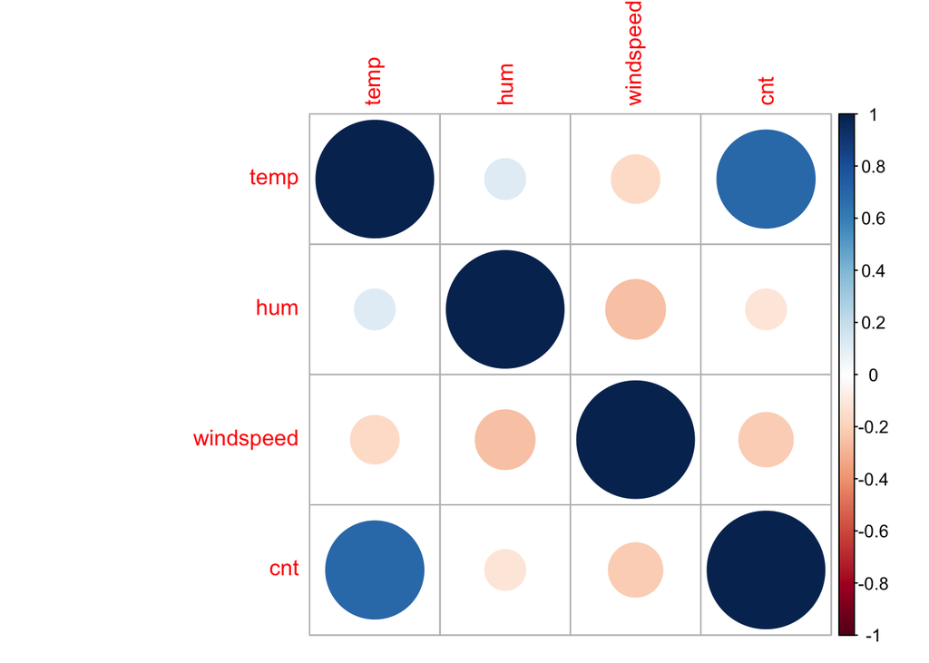

```r
corrplot(cor(bikeTrain[,8:11]))
```

### LMG

Problems with variable 6, removed for the LMG-method.

```r
library("relaimpo")
calc.relimp(cnt~., data=bikeTrain|,-6], type="lmg",rela=TRUE)
rev(sort(crf$lmg))
```

### ALE and PDP for RF

```r
# ICE
X=model.matrix(~.-cnt,data=bike)
rf=randomForest(y=bike$cnt, x=X,ntree=50,  importance=TRUE)
this=ice(rf,X=X,predictor=27,plot=TRUE)
```

[output not shown]

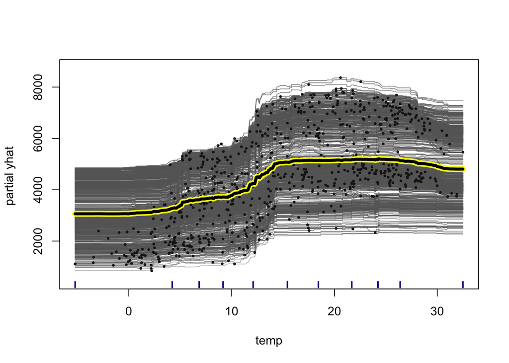

```r
plot(this,centered=FALSE,xlab="temp",frac_to_plot=1,plot_orig_pts_preds=TRUE,pts_preds_size=0.5)
```

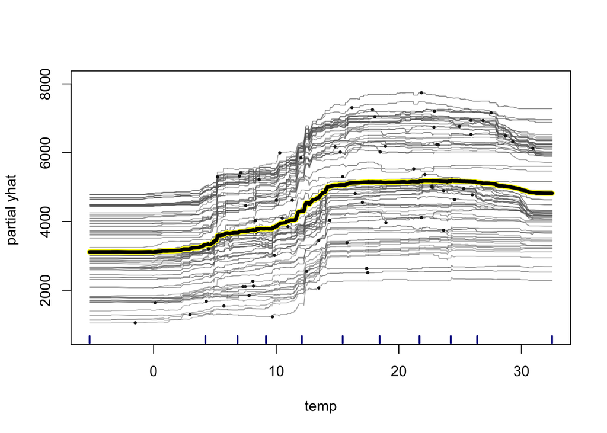

```r
plot(this,centered=FALSE,xlab="temp",frac_to_plot=0.1,plot_orig_pts_preds=TRUE,pts_preds_size=0.5)
```

```r
rf=randomForest(cnt ~ ., data = bike, ntree = 50)
print(rf)
```

```
##
## Call:
##  randomForest(formula = cnt ~ ., data = bike, ntree = 50)
##                Type of random forest: regression
##                      Number of trees: 50
## No. of variables tried at each split: 3
##
##           Mean of squared residuals: 454362.8
##                     % Var explained: 87.88
```

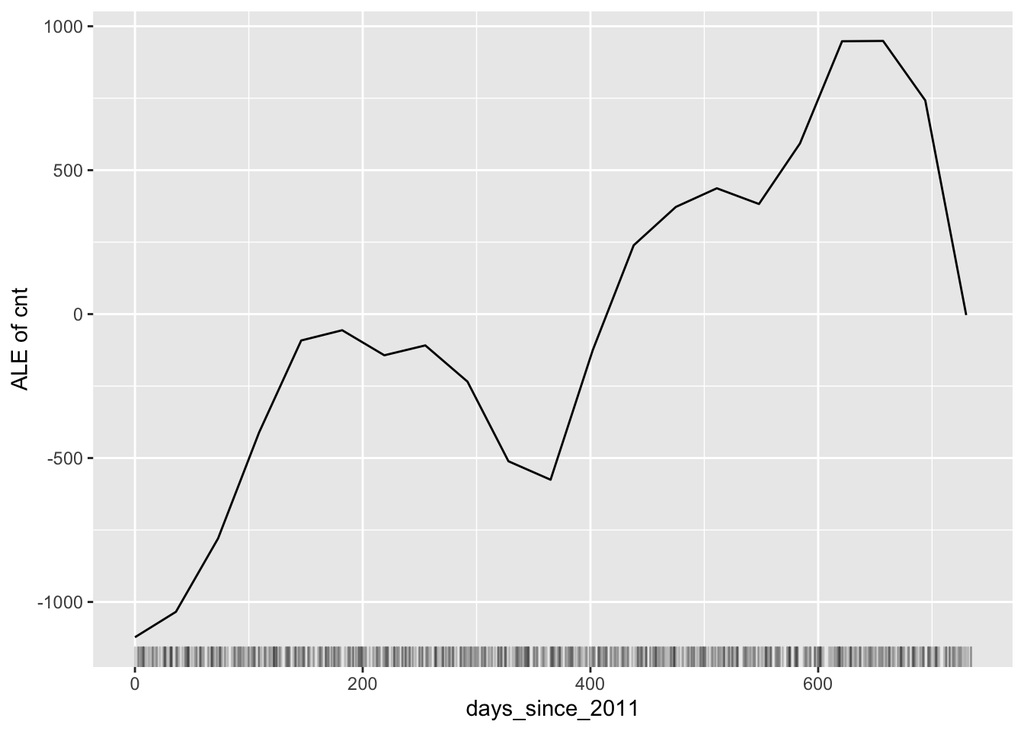

```r
mod=Predictor$new(rf, data = bike)


eff1=FeatureEffect$new(mod, feature = "days_since_2011", method="ale")
plot(eff1)
```

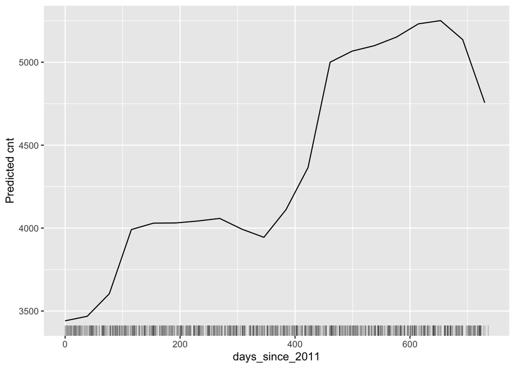

```r
eff2=FeatureEffect$new(mod, feature = "days_since_2011", method="pdp")
plot(eff2)
```

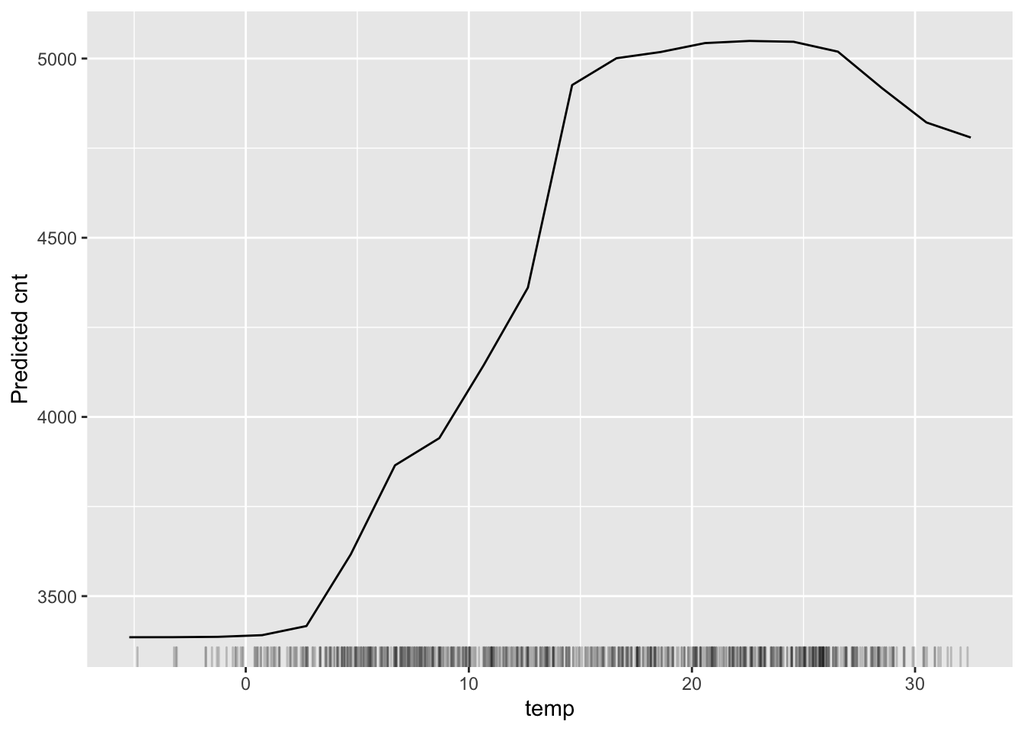

```r
#PD plot
eff1=FeatureEffect$new(mod, feature = "temp", method="pdp")
plot(eff1)
```

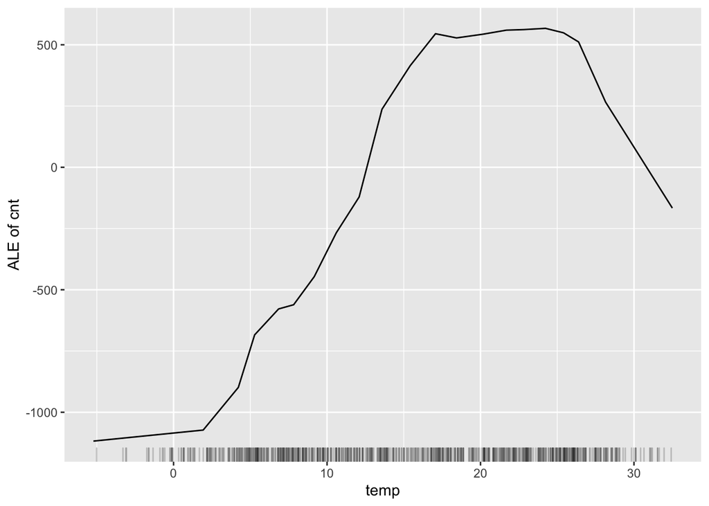

```r
#ALE plot
eff2=FeatureEffect$new(mod, feature = "temp", method="ale")
plot(eff2)
```

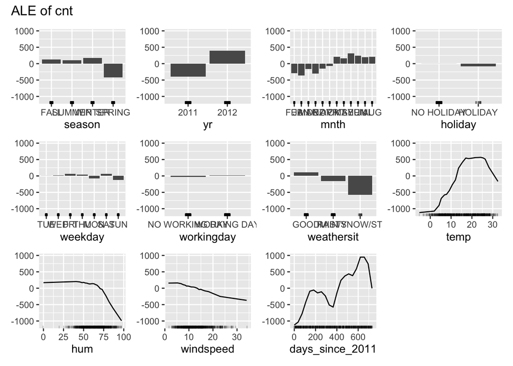

```r
eff<-FeatureEffects$new(mod, method="ale")
eff$plot()
```

```r
#eff<-FeatureEffects$new(mod, method="ice",feature="temp")
#eff$plot()
```

### ALE and PDP for xgboost

```r
library(xgboost)
n<-dim(bike)[1]
bikeTrain<-bike[1:600,]
bikeTest<-bike[601:n,]
xgb.train=xgb.DMatrix(data = as.matrix(sapply(bikeTrain[,-11], as.numeric)),label = bikeTrain[,"cnt"])
xgb.test<-xgb.DMatrix(data = as.matrix(sapply(bikeTest[,-11], as.numeric)),label = bikeTest[,"cnt"])

params<-list(eta = 0.1,
objective = "reg:squarederror",
eval_metric = "rmse",
tree_method="hist") # gpu_hist
#RNGversion(vstr = "3.5.0")
set.seed(12345)

model<-xgb.train(data = xgb.train,
params = params,
nrounds = 50,
print_every_n = 10,
ntread = 5,
watchlist = list(train = xgb.train,
test = xgb.test),
verbose = 1)
```

[output not shown]

```r
xgb.importance(model=model)
```

```
##             Feature         Gain        Cover   Frequency
##  1: days_since_2011 0.7976586942 0.3430909388 0.162966462
##  2:            temp 0.1132748771 0.2445233763 0.239017478
##  3:             hum 0.0295591111 0.1416631672 0.180444025
##  4:      weathersit 0.0213787474 0.0364816629 0.049598488
##  5:       windspeed 0.0192767348 0.0998856850 0.145488899
##  6:         weekday 0.0055235470 0.0546554218 0.091639112
##  7:            mnth 0.0054333041 0.0396486562 0.056683987
##  8:          season 0.0031174028 0.0115831467 0.024090694
##  9:      workingday 0.0023060841 0.0175030328 0.033065659
## 10:         holiday 0.0021865526 0.0105916387 0.013698630
## 11:              yr 0.0002849447 0.0003732736 0.003306566
```

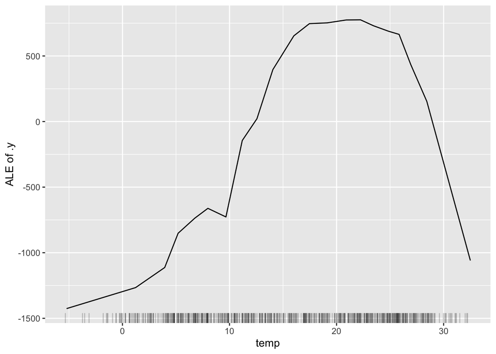

```r
# 1. create a data frame with just the features
features<-bikeTrain[,-11]
# 2. Create a vector with the actual responses
response<-bikeTrain[,"cnt"]
# 3. Create custom predict function that returns the predicted values as a vector
pred<-function(model, newdata)
{
#xgb.test<-xgb.DMatrix(data = as.matrix(sapply(newdata[,‐11], as.numeric)),label = newdata[,11])
xgb.test<-xgb.DMatrix(data = as.matrix(sapply(newdata, as.numeric)))
results<-predict(model,newdata=xgb.test)
#return(results[[3L]])
return(results)
}
#4. Define predictor
predictor.xgb<-Predictor$new(
model = model,
data = features,
y = response,
predict.fun = pred,
class = "regression"
)
#5. Compute feature effects
eff<-FeatureEffect$new(predictor.xgb, feature = "temp", method="ale")
plot(eff)
```

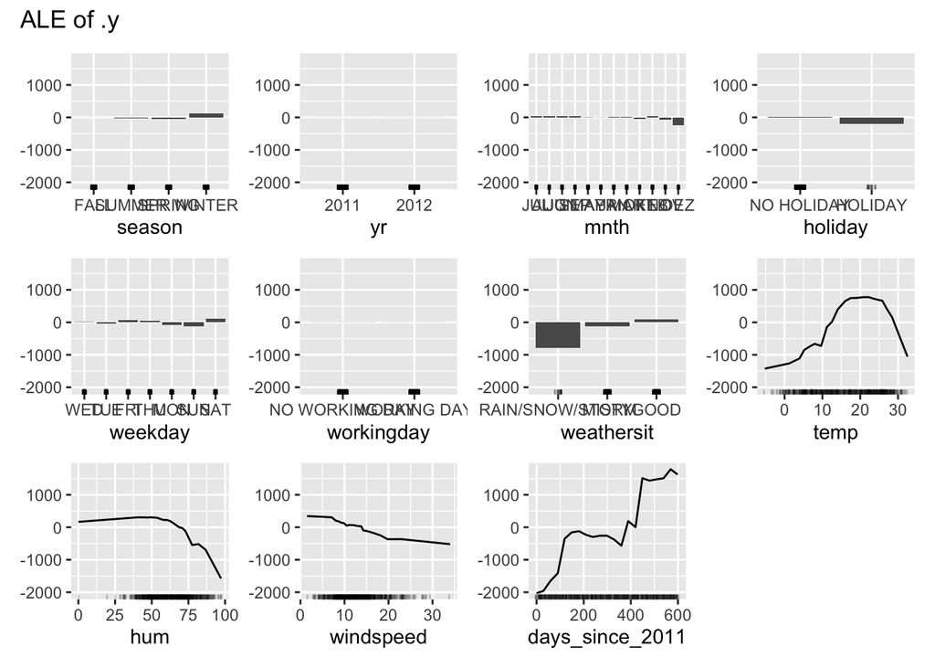

```r
eff<-FeatureEffects$new(predictor.xgb, method="ale")
eff$plot()
```

## References for further reading

- LMG: the method is nicely explained in Grömping (2007)
- ICEplot: Goldstein et al. (2015)
- ALEplot: Apley and Zhu (2020)
- PDPplot: Friedman, Hastie, and Tibshirani (2001) chapter 10.13.2

# L12: LIME slide set

## R-code

Fitting random forest with the ranger package to the bike data.

```r
library(lime)
library(ranger)
predict_model.ranger <- function(x,newdata,type)
{
pred.rf <- predict(x, data = newdata)
switch(
type,
raw = data.frame(Response = res$class, stringsAsFactors = FALSE),
prob = as.data.frame(pred.rf$predictions[,2])
)
}

model_type.ranger <- function(x, ...)
{
'regression'
}

model<- ranger(cnt ~ ., data = bikeTrain, num.trees = 50, num.threads = 6,
verbose = TRUE,
probability = FALSE,
importance = "impurity",
mtry = sqrt(27))

print(model)
```

```
## Ranger result
##
## Call:
##  ranger(cnt ~ ., data = bikeTrain, num.trees = 50, num.threads = 6,      verbose = TRUE, probability = FALSE, importance = "impurity",      mtry = sqrt(27))
##
## Type:                             Regression
## Number of trees:                  50
## Sample size:                      600
## Number of independent variables:  11
## Mtry:                             5
## Target node size:                 5
## Variable importance mode:         impurity
## Splitrule:                        variance
## OOB prediction error (MSE):       369032.2
## R squared (OOB):                  0.8889208
```

Using `lime` to explain the random forest for test observationos 10:14 using `n_features=5` and `kernel_width=3`.

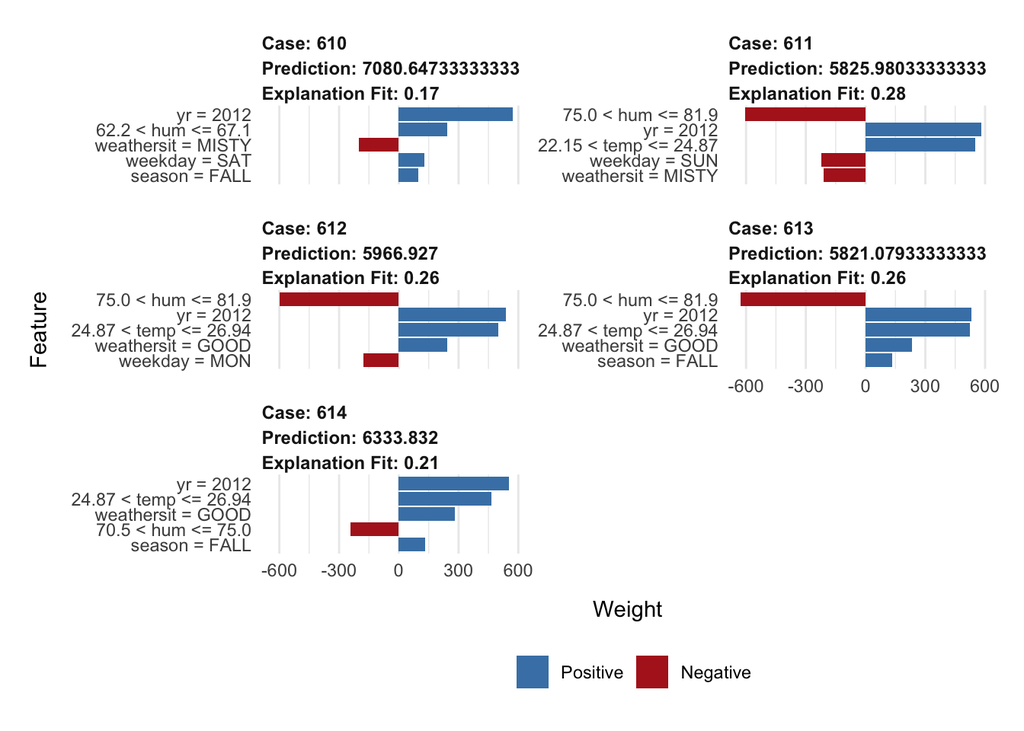

```r
explainer <- lime::lime(
bikeTrain,
model = model,
#bin_continuous = FALSE
bin_continuous = TRUE,
n_bins = 10,
quantile_bins=TRUE
)
explanationLime <- explain(
bikeTest[10:14,-11],
explainer = explainer,
#n_labels = 1,
n_features = 5,
n_permutations = 5000,
feature_select = "auto",
kernel_width = 3)
lime::plot_features(explanationLime,
ncol = 2)
```

## References for further reading

- The original LIME article Ribeiro, Singh, and Guestrin (2016)
- this blog post by the authors https://www.oreilly.com/content/introduction-to-local-interpretable-model-agnostic-explanations-lime/

# References

Apley, Daniel W., and Jingyu Zhu. 2020. “Visualizing the Effects of Predictor Variables in Black Box Supervised Learning Models.” *Journal of the Royal Statistical Society: Series B (Statistical Methodology)* 82 (4): 1059–86. https://doi.org/https://doi.org/10.1111/rssb.12377.

Friedman, Jerome, Trevor Hastie, and Robert Tibshirani. 2001. *The Elements of Statistical Learning*. Vol. 1. Springer series in statistics New York.

Goldstein, Alex, Adam Kapelner, Justin Bleich, and Emil Pitkin. 2015. “Peeking Inside the Black Box: Visualizing Statistical Learning with Plots of Individual Conditional Expectation.” *Journal of Computational and Graphical Statistics* 24 (1): 44–65. https://doi.org/10.1080/10618600.2014.907095.

Grömping, U. 2007. “Estimators of Relative Importance in Linear Regression Based on Variance Decomposition.” *The American Statistician* 61: 139–47.

Molnar, Christoph. 2019. *Interpretable Machine Learning: A Guide for Making Black Box Models Explainable*.

Ribeiro, Marco Tulio, Sameer Singh, and Carlos Guestrin. 2016. “"Why Should i Trust You?": Explaining the Predictions of Any Classifier.” In *Proceedings of the 22nd ACM SIGKDD International Conference on Knowledge Discovery and Data Mining*, 1135–44. KDD ’16. New York, NY, USA: Association for Computing Machinery. https://doi.org/10.1145/2939672.2939778.